# **Accessing and Predicting Customer Satisfaction for Airline Data**

A Data Science Project by Dhvani Patel, Nidhi Challa, and Shivasree Margam

## **Introduction**

Hello! Welcome to our Data Science Tutorial. Within this project, we have decided to analyze customer satisfaction within the airline industry using a Kaggle dataset containing personal data from an anonymous airline passenger satisfaction survey. Analyzing customer sentiment plays a vital role in helping airline companies pinpoint what amenities and services passengers love and don’t love so they can focus on problem areas and improve them. According to a study conducted by PwC, 59 percent of U.S. consumers would refuse to buy from a company after several poor experiences. In order to improve the business model within the airline industry, it is important to shift towards a more data-science approach by using customer analytics and machine learning to predict the factors that attract the most customers.

This dataset has information for over 120k passengers with factors influencing passenger satisfaction on an airflight journey. Some features include basic passenger/flight information such as type of travel, class, flight distance, as well as survey results such as food and drink, seat comfort, and inflight entertainment rankings.

Our goal is to predict passenger satisfaction using pre-labeled training data by creating classification models and comparing these models to achieve high accuracy.

The dataset: https://www.kaggle.com/teejmahal20/airline-passenger-satisfaction

## **Set Up**

Within this project, we used basic data science and machine learning packages to analyze training data through the creation of various graphs and predict satisfaction within the testing set using classifiers.

```python
# import necessary packages
import pandas as pd
import numpy as np
import matplotlib.pyplot as plt
from sklearn.model_selection import train_test_split
import seaborn as sns
from sklearn.tree import DecisionTreeClassifier
from sklearn.ensemble import RandomForestClassifier
from sklearn.metrics import recall_score, precision_score
from sklearn.metrics import accuracy_score, confusion_matrix
from sklearn import preprocessing
from sklearn import tree
from sklearn.linear_model import LogisticRegression
from sklearn.metrics import plot_precision_recall_curve
import sklearn.metrics as metrics
```

## **Data Extraction and Cleaning**

The dataset from Kaggle comes in as pre-split training and testing data so after loading it in from this [link](https://www.kaggle.com/teejmahal20/airline-passenger-satisfaction) we merged the data to perform some cleaning. Unnecessary columns such as 'id' were dropped and 'satisfied' was set to 1 whereas 'neutral or dissatisfied' is now 0 making this a binary classification problem.

```python
# read the data in
train_df = pd.read_csv('airline_train.csv') # contains 80% of total data
test_df = pd.read_csv('airline_test.csv') # contains 20% of total data

# merge data, perform cleaning, then split again
merged_df = pd.concat([train_df, test_df])

# remove unnamed column from dataset
merged_df = merged_df.drop(['Unnamed: 0'], axis=1)
merged_df = merged_df.drop(['id'], axis=1)

# satisfied = 1 and neutral or dissatisfied = 0
merged_df['satisfaction'] = np.where(merged_df['satisfaction'] == 'satisfied', 1, merged_df['satisfaction'])
merged_df['satisfaction'] = np.where(merged_df['satisfaction'] == 'neutral or dissatisfied', 0, merged_df['satisfaction'])

# fill missing data within 'Arrival Delay in Minutes' with 0
merged_df['Arrival Delay in Minutes'] = merged_df['Arrival Delay in Minutes'].fillna(0)

# split data into 80% training and 20% testing data
training_data, testing_data = train_test_split(merged_df, test_size=0.2, random_state=25)

training_data.head(5)
```

|  | Gender | Customer Type | Age | Type of Travel | Class | Flight Distance | Inflight wifi service | Departure/Arrival time convenient | Ease of Online booking | Gate location | Food and drink | Online boarding | Seat comfort | Inflight entertainment | On-board service | Leg room service | Baggage handling | Checkin service | Inflight service | Cleanliness | Departure Delay in Minutes | Arrival Delay in Minutes | satisfaction |
| --- | --- | --- | --- | --- | --- | --- | --- | --- | --- | --- | --- | --- | --- | --- | --- | --- | --- | --- | --- | --- | --- | --- | --- |
| 80057 | Female | Loyal Customer | 37 | Business travel | Business | 3403 | 1 | 1 | 1 | 1 | 5 | 4 | 4 | 4 | 4 | 4 | 5 | 4 | 4 | 3 | 0 | 0.0 | 1 |
| 19133 | Male | disloyal Customer | 27 | Business travel | Business | 268 | 0 | 0 | 0 | 2 | 2 | 0 | 2 | 2 | 3 | 4 | 5 | 5 | 4 | 2 | 0 | 21.0 | 1 |
| 16492 | Male | disloyal Customer | 27 | Business travel | Business | 733 | 5 | 5 | 5 | 2 | 4 | 5 | 1 | 4 | 5 | 2 | 5 | 3 | 4 | 4 | 23 | 8.0 | 1 |
| 66556 | Female | Loyal Customer | 24 | Personal Travel | Eco | 337 | 3 | 4 | 3 | 4 | 3 | 3 | 3 | 3 | 3 | 4 | 3 | 5 | 2 | 3 | 0 | 0.0 | 0 |
| 43667 | Female | Loyal Customer | 53 | Business travel | Business | 2381 | 1 | 4 | 4 | 4 | 5 | 3 | 2 | 3 | 3 | 3 | 1 | 1 | 3 | 3 | 0 | 0.0 | 0 |

# **Data Exploration and Analysis**

In order to better understand the data, we performed a series of steps to visualize the dataframe columns with respect to the target variable (satisfaction).

**Visualizing Satisfaction by Age Group**

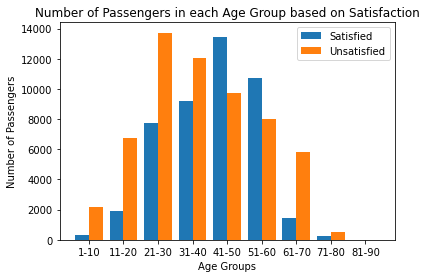

```python
# lets understand the correlation between age and satisfaction

copy_table = training_data
copy_table['age range'] = pd.cut(copy_table.Age, [0,10, 20, 30, 40, 50, 60, 70, 80, 90])

satisfied_dict = {'(0, 10]': {'satisfied': 0, 'unsatisfied': 0},'(10, 20]': {'satisfied': 0, 'unsatisfied': 0},
                  '(20, 30]': {'satisfied': 0, 'unsatisfied': 0},'(30, 40]':{'satisfied': 0, 'unsatisfied': 0},
                  '(40, 50]':{'satisfied': 0, 'unsatisfied': 0}, '(50, 60]':{'satisfied': 0, 'unsatisfied': 0},
                  '(60, 70]':{'satisfied': 0, 'unsatisfied': 0}, '(70, 80]':{'satisfied': 0, 'unsatisfied': 0},
                  '(80, 90]':{'satisfied': 0, 'unsatisfied': 0}}


for row_index, row in copy_table.iterrows():
    age_range = row['age range']
    satisfied = row['satisfaction']

    if satisfied == 1:

        satisfied_dict[str(age_range)]['satisfied'] +=1
    else:
        satisfied_dict[str(age_range)]['unsatisfied'] +=1


x_labels = ['1-10', '11-20', '21-30', '31-40', '41-50', '51-60', '61-70', '71-80', '81-90']
satisfied = []
unsatisfied = []
for k,v in satisfied_dict.items():
    satisfied.append(v['satisfied'])
    unsatisfied.append(v['unsatisfied'])

x_axis = np.arange(len(x_labels))

plt.bar(x_axis - 0.2, satisfied, 0.4, label = 'Satisfied')
plt.bar(x_axis + 0.2, unsatisfied, 0.4, label = 'Unsatisfied')

plt.xticks(x_axis, x_labels)
plt.xlabel("Age Groups")
plt.ylabel("Number of Passengers")
plt.title("Number of Passengers in each Age Group based on Satisfaction")
plt.legend()

plt.show()
```

**Which non-binary categories are most related to one another?**

Below a correlation matrix has been created which shows the strength of relationship between two variables. A correlation matrix is often used to summarize the outworldly influence each variable has on another and vice versa to better input features for hypothesis testing. In the matrix below, the lighter colors represent high correlation whereas the dark purple colors show weak correlation. The correlation a variable has to itself will always be one.

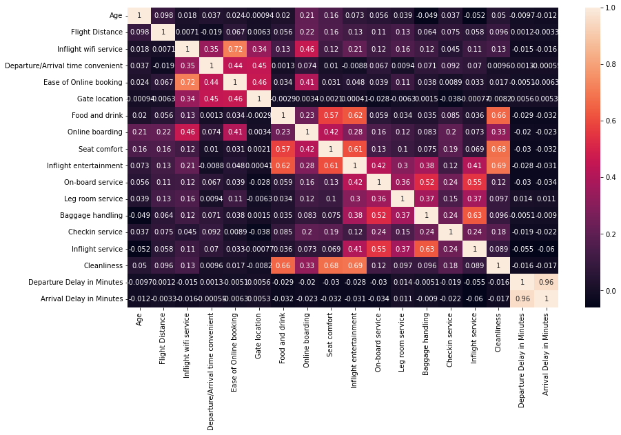

```python
# which rating category was most associated with a satified overall review and which was most associated with a unsatisfied overall review
# comparison between total rating and Class
correlation = training_data.corr()

plt.figure(figsize = (14,8))

sns.heatmap(correlation, annot=True, cbar=True)
```

According to our correlation matrix, the factors arrival delay in minutes and departure delay in minutes are highly correlated(0.96) which makes sense considering that if a flight is late to depart an airport location, it will likely arrive at the new location late as well. Other factors that are highly correlated with a value of 0.66 are Food & Drink and Cleanliness. Since the presence of food can affect the overall custodial maintenance of the aircraft, it is expected that these two features have high influence over one another.

**Which Survey Categories have the highest and lowest rating?**

Now that we understand the relationship between survey categories, let's try to analyze their influence over satisfaction. First we created a bar graph plotting the average rating per category.

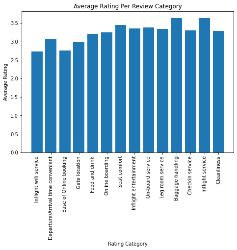

```python
# bar graph of average rating per column

rating_columns = ['Inflight wifi service', 'Departure/Arrival time convenient', 'Ease of Online booking',	'Gate location',	'Food and drink',	'Online boarding', 'Seat comfort', 'Inflight entertainment', 'On-board service', 'Leg room service', 'Baggage handling', 'Checkin service', 'Inflight service', 'Cleanliness']
means = []
for col in rating_columns:
  means.append(training_data[col].mean())

fig = plt.figure()
ax = fig.add_axes([0,0,1,1])
ax.bar(rating_columns,means)
y_pos = range(len(rating_columns))
plt.xticks(y_pos, rating_columns, rotation=90)
plt.title("Average Rating Per Review Category")
plt.xlabel("Rating Category")
plt.ylabel("Average Rating")
plt.show()
```

**Analyze Customer Satisfaction**

The dataset displays customer satisfaction spread throughout many categories on a 0 to 5 scale in addition to a general satisfaction column where a customer is satisfied or neutral/not-satisfied. Having the numeric customer satisfaction spread across many columns makes it difficult to determine the overall customer's satisfaction. In addition to that, a column that lumps a customer feeling neutral alongside a customer feeling not satisfied also makes it difficult to have an in-depth understanding of the customer's experience. As a solution to this, we decided it would be best to create a new column called "total_satisfaction" that sums up columns 7 through 20, which are columns that have the 0 to 5 scale based on customer's experiences in those various categories. The idea is that "total_satisfaction" offers a more in depth understanding of a customer's experience and is a better overall tool for us to use when visualizing and analyzing the data.

```python
column_names = ['Inflight wifi service', 'Departure/Arrival time convenient', 'Ease of Online booking', 'Gate location','Food and drink', 'Food and drink', 'Online boarding', 'Seat comfort','Inflight entertainment','On-board service', 'Leg room service', 'Baggage handling', 'Checkin service', 'Inflight service', 'Cleanliness']
training_data['total_satisfaction']= training_data[column_names].sum(axis=1)
```

```python
total_sat_data = training_data.copy()
total_sat_data.drop(total_sat_data.iloc[:, 6:20], inplace = True, axis = 1)
total_sat_data.head()
```

|  | Gender | Customer Type | Age | Type of Travel | Class | Flight Distance | Departure Delay in Minutes | Arrival Delay in Minutes | satisfaction | age range | total_satisfaction |
| --- | --- | --- | --- | --- | --- | --- | --- | --- | --- | --- | --- |
| 80057 | Female | Loyal Customer | 37 | Business travel | Business | 3403 | 0 | 0.0 | 1 | (30, 40] | 50 |
| 19133 | Male | disloyal Customer | 27 | Business travel | Business | 268 | 0 | 21.0 | 1 | (20, 30] | 33 |
| 16492 | Male | disloyal Customer | 27 | Business travel | Business | 733 | 23 | 8.0 | 1 | (20, 30] | 58 |
| 66556 | Female | Loyal Customer | 24 | Personal Travel | Eco | 337 | 0 | 0.0 | 0 | (20, 30] | 49 |
| 43667 | Female | Loyal Customer | 53 | Business travel | Business | 2381 | 0 | 0.0 | 0 | (50, 60] | 45 |

We created another correlation matrix mainly to see the relationship between the total satisfaction of a passenger and all the other columns.

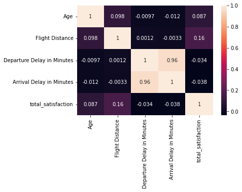

```python
correlation = total_sat_data.corr()
sns.heatmap(correlation, annot=True, cbar=True)
```

[output not shown]

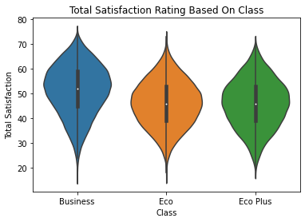

```python
total_sat_violin_plot = sns.violinplot(x=total_sat_data['Class'],
                                    y=total_sat_data['total_satisfaction'])
total_sat_violin_plot.set(xlabel='Class',
                       ylabel='Total Satisfaction',
                       title='Total Satisfaction Rating Based On Class')
```

The distribution of total satisfaction between all the classes seems to be about the same with satisfaction in business class skewing on the higher end and the economic and economic plus class being around the same. An explanation for why business class skews on the higher end for satisfaction could be because passengers that fly business class pay more for a better experience, like the airplane seats being more comfortable and with more leg room.

[output not shown]

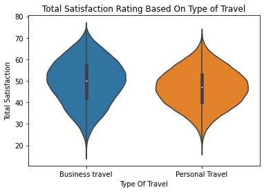

```python
total_sat_violin_plot2 = sns.violinplot(x=total_sat_data['Type of Travel'],
                                    y=total_sat_data['total_satisfaction'])
total_sat_violin_plot2.set(xlabel='Type Of Travel',
                       ylabel='Total Satisfaction',
                       title='Total Satisfaction Rating Based On Type of Travel')
```

Based on the violin plot above, looking at the satisfaction and type of travel, it looks like those that are traveling for business tend to be more satisfied with their travel experience. A reason for this could be that more people that travel for business use business class, and as we saw in the violin plot above this that those traveling business class tend to have a better experience overall. So to see if it's true that those that travel for business are more likely to travel business class, let's see the ratio of what class passengers travel based on the reason they're traveling below.

```python
total_business = len(total_sat_data.loc[total_sat_data['Type of Travel'] == "Business travel"])
total_personal = len(total_sat_data.loc[total_sat_data['Type of Travel'] == "Personal Travel"])

business_business = len(total_sat_data[(total_sat_data["Type of Travel"] == "Business travel") & (total_sat_data['Class'] == "Business")])/total_business * 100
business_eco = len(total_sat_data[(total_sat_data["Type of Travel"] == "Business travel") & (total_sat_data['Class'] == "Eco")])/total_business * 100
business_plus = len(total_sat_data[(total_sat_data["Type of Travel"] == "Business travel") & (total_sat_data['Class'] == "Eco Plus")])/total_business * 100

personal_business = len(total_sat_data[(total_sat_data["Type of Travel"] == "Personal Travel") & (total_sat_data['Class'] == "Business")])/total_personal * 100
personal_eco = len(total_sat_data[(total_sat_data["Type of Travel"] == "Personal Travel") & (total_sat_data['Class'] == "Eco")])/total_personal * 100
personal_plus = len(total_sat_data[(total_sat_data["Type of Travel"] == "Personal Travel") & (total_sat_data['Class'] == "Eco Plus")])/total_personal * 100
```

```python
print("Traveling for business using business class: " + str(business_business) + "%")
print("Traveling for business using economy class: " + str(business_eco) + "%")
print("Traveling for business using economy plus class: " + str(business_plus) + "%\n")

print("Traveling for personal reasons using business class: " + str(personal_business) + "%")
print("Traveling for personal reasons using economy class: " + str(personal_eco) + "%")
print("Traveling for personal reasons using economy plus class: " + str(personal_plus) + "%")
```

```
Traveling for business using business class: 66.15007247184748%
Traveling for business using economy class: 28.344854498829303%
Traveling for business using economy plus class: 5.505073029323224%

Traveling for personal reasons using business class: 6.643443642697189%
Traveling for personal reasons using economy class: 82.15352077631252%
Traveling for personal reasons using economy plus class: 11.203035580990296%
```

The majority of those traveling for business use business class, which is normally more expensive but also means that passengers normally get better service and extra perks. On the other hand, a larger majority of those traveling for personal reasons fly economy class. This could offer a reason as to why those that travel for business reasons tend to be more satisfied than those that don't.

[output not shown]

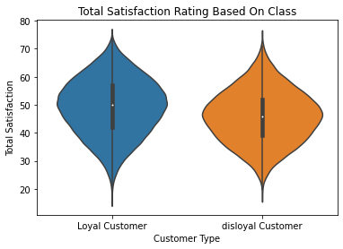

```python
total_sat_violin_plot3 = sns.violinplot(x=total_sat_data['Customer Type'],
                                    y=total_sat_data['total_satisfaction'])
total_sat_violin_plot3.set(xlabel='Customer Type',
                       ylabel='Total Satisfaction',
                       title='Total Satisfaction Rating Based On Class')
```

The dataset we're using for this analysis is from kaggle and doesn't give much of a description on what loyal and disloyal customers are. Our best guess is that "loyal" might have to do with a customer being part of some loyalty program. This is supported by loyal customers overall having a better experience than "disloyal" customers. But it's hard to be 100% sure on that.

```python
#Random sample of the customer data so that the scatter plots below are readable
ran_data = total_sat_data.sample(frac=0.1, replace=True, random_state=1)
```

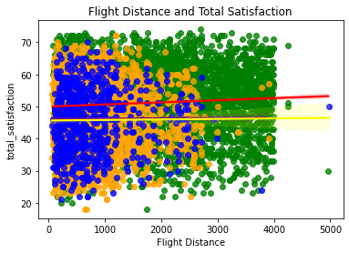

```python
business = ran_data.loc[ran_data['Class'] == "Business"]
eco = ran_data.loc[ran_data['Class'] == "Eco"]
eco_plus = ran_data.loc[ran_data['Class'] == "Eco Plus"]

title = "Flight Distance and Total Satisfaction"

sns.regplot(x="Flight Distance", y="total_satisfaction", data=business, scatter_kws={"color": "green"}, line_kws={"color": "red"}, label='business').set(title=title)

sns.regplot(x="Flight Distance", y="total_satisfaction", data=eco, scatter_kws={"color": "orange"}, line_kws={"color": "purple"}, label = 'eco')

sns.regplot(x="Flight Distance", y="total_satisfaction", data=eco_plus, scatter_kws={"color": "blue"}, line_kws={"color": "yellow"}, label = 'eco plus')
```

- Green dots and red line = business class
- Orange dots and purple line = eco class
- Blue dots and yellow line = eco plus class

There's a lot of factors that go into what makes a customer have a good or bad experience on a flight. Some of those reasons can be a direct thing like a rude flight attendant or damaged luggage but some might not be so obvious. One thought we had was that longer flights might contribute to a customer being overall more irritable so that might be a reason that they would have a more poor travel experience. In order to look at that in a more detailed way, we created a scatter plot

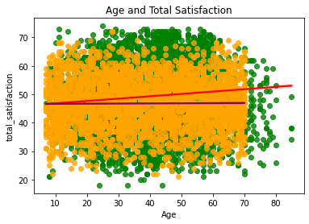

```python
business = ran_data.loc[ran_data['Type of Travel'] == "Business travel"]
personal = ran_data.loc[ran_data['Type of Travel'] == "Personal Travel"]

title = "Age and Total Satisfaction"

sns.regplot(x="Age", y="total_satisfaction", data=business, scatter_kws={"color": "green"}, line_kws={"color": "red"}, label='business').set(title=title)

sns.regplot(x="Age", y="total_satisfaction", data=personal, scatter_kws={"color": "orange"}, line_kws={"color": "purple"}, label = 'personal')
```

- Green dots and red line = business travel
- Orange dots and purple line = personal travel

Another potential significant influence on the total satisfaction of a customer is age. Looking at this scatter plot it looks like age has little to no influence on satisfaction when it comes to personal travel. On the other hand, it looks like there's some increased satisfaction with an increase in age for those traveling for business

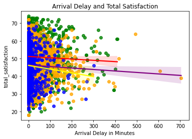

```python
business = ran_data.loc[ran_data['Class'] == "Business"]
eco = ran_data.loc[ran_data['Class'] == "Eco"]
eco_plus = ran_data.loc[ran_data['Class'] == "Eco Plus"]

title = "Arrival Delay and Total Satisfaction"

sns.regplot(x="Arrival Delay in Minutes", y="total_satisfaction", data=business, scatter_kws={"color": "green"}, line_kws={"color": "red"}).set(title=title)

sns.regplot(x="Arrival Delay in Minutes", y="total_satisfaction", data=eco, scatter_kws={"color": "orange"}, line_kws={"color": "purple"})

sns.regplot(x="Arrival Delay in Minutes", y="total_satisfaction", data=eco_plus, scatter_kws={"color": "blue"}, line_kws={"color": "yellow"})
```

- Green dots and red line = business class
- Orange dots and purple line = eco class
- Blue dots and yellow line = eco plus class

```
[Text(0.5, 1.0, 'Online Boarding vs Inflight Wifi Service')]
```

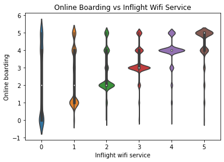

```python
#correlation between online boarding and inflight wifi service
title = 'Online Boarding vs Inflight Wifi Service'
sns.violinplot(x=merged_df['Inflight wifi service'], y = merged_df['Online boarding']).set(title = title)
```

Looking at the violin plot above, we can clearly say that the inflight wifi service and online boarding are positively correlated. From this, it is implied that the customer satisfaction also depends on these two factors. In other words, if one of them is disrupted, it could impact the other one, bringing down the total customer satisfaction

## Classifiers

```python
#classification
feature_cols = ['Gender','Customer Type','Age','Type of Travel','Class','Flight Distance','Inflight wifi service','Departure/Arrival time convenient','Ease of Online booking','Gate location','Food and drink','Online boarding','Seat comfort','Inflight entertainment','On-board service','Leg room service','Baggage handling','Checkin service','Inflight service','Cleanliness','Departure Delay in Minutes','Arrival Delay in Minutes']

#converting string values to float values
le = preprocessing.LabelEncoder()
merged_df = merged_df.apply(le.fit_transform)

X = merged_df[feature_cols]
y = merged_df.satisfaction
X_train, X_test, y_train, y_test = train_test_split(X, y, test_size=0.2)
```

Decision Tree

```
recall score for decision tree: 0.9428470003549876
precision score for decision tree: 0.9388476493460587
accuracy score for decision tree: 0.9485679088389283
```

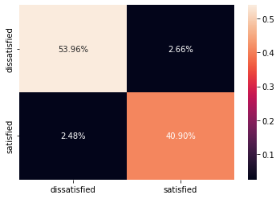

```python
#decision tree classification
decision_tree = DecisionTreeClassifier()
decision_tree = decision_tree.fit(X_train,y_train)
y_pred = decision_tree.predict(X_test)
dt_recall_score = recall_score(y_test, y_pred)
dt_precision_score = precision_score(y_test, y_pred)
dt_accuracy_score = accuracy_score(y_test, y_pred)
percent = (confusion_matrix(y_test,y_pred))/ np.sum((confusion_matrix(y_test,y_pred)))

print("recall score for decision tree: " + str(dt_recall_score))
print("precision score for decision tree: " + str(dt_precision_score))
print("accuracy score for decision tree: " + str(dt_accuracy_score) + "\n")

sns.heatmap(percent,annot=True,fmt='.2%', xticklabels=["dissatisfied","satisfied"], \
            yticklabels=["dissatisfied","satisfied"])
```

Random Forest

```
recall score for decision tree: 0.9447994320198793
precision score for decision tree: 0.9740164684354986
accuracy score for decision tree: 0.9651216507545427
```

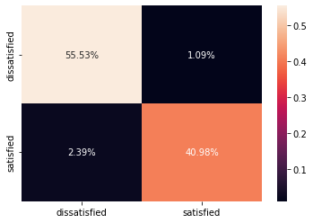

```python
#random forest classification
random_forest = RandomForestClassifier()
random_forest = random_forest.fit(X_train,y_train)
y_pred = random_forest.predict(X_test)
rf_recall_score = recall_score(y_test, y_pred)
rf_precision_score = precision_score(y_test, y_pred)
rf_accuracy_score = accuracy_score(y_test, y_pred)
percent = (confusion_matrix(y_test,y_pred))/ np.sum((confusion_matrix(y_test,y_pred)))

print("recall score for decision tree: " + str(rf_recall_score))
print("precision score for decision tree: " + str(rf_precision_score))
print("accuracy score for decision tree: " + str(rf_accuracy_score) + "\n")

sns.heatmap(percent,annot=True,fmt='.2%', xticklabels=["dissatisfied","satisfied"], \
            yticklabels=["dissatisfied","satisfied"])
```

Logistic Regression

```
recall score for decision tree: 0.8016506922257721
precision score for decision tree: 0.7983913735195334
accuracy score for decision tree: 0.8261472128118263
```

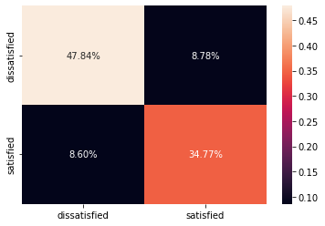

```python
#logistic regression classification
log_reg=LogisticRegression()
log_reg.fit(X_train,y_train)
y_pred=log_reg.predict(X_test)

lg_recall_score = recall_score(y_test, y_pred)
lg_precision_score = precision_score(y_test, y_pred)
lg_accuracy_score = accuracy_score(y_test, y_pred)
percent = (confusion_matrix(y_test,y_pred))/ np.sum((confusion_matrix(y_test,y_pred)))

print("recall score for decision tree: " + str(lg_recall_score))
print("precision score for decision tree: " + str(lg_precision_score))
print("accuracy score for decision tree: " + str(lg_accuracy_score) + "\n")

sns.heatmap(percent,annot=True,fmt='.2%', xticklabels=["dissatisfied","satisfied"], \
            yticklabels=["dissatisfied","satisfied"])
```

# AUC Scores

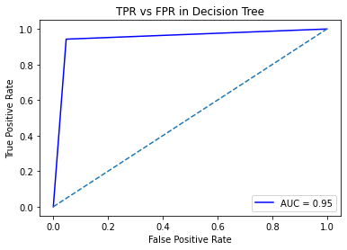

```python
# fpr and tpr for all thresholds of the decision tree

prediction = decision_tree.predict_proba(X_test)[:,1]
fpr, tpr, threshold = metrics.roc_curve(y_test, prediction)
roc_auc = metrics.auc(fpr, tpr)

plt.title('TPR vs FPR in Decision Tree')
plt.plot(fpr, tpr, 'b', label = 'AUC = %0.2f' % roc_auc)
plt.legend()
plt.plot([0, 1], [0, 1],'--')
plt.ylabel('True Positive Rate')
plt.xlabel('False Positive Rate')
plt.show()
```

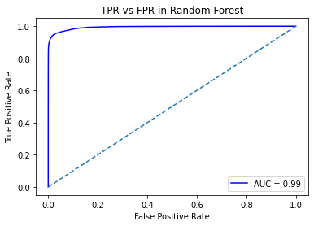

```python
# fpr and tpr for all thresholds of the random forest

prediction = random_forest.predict_proba(X_test)[:,1]
fpr, tpr, threshold = metrics.roc_curve(y_test, prediction)
roc_auc = metrics.auc(fpr, tpr)

plt.title('TPR vs FPR in Random Forest')
plt.plot(fpr, tpr, 'b', label = 'AUC = %0.2f' % roc_auc)
plt.legend()
plt.plot([0, 1], [0, 1],'--')
plt.ylabel('True Positive Rate')
plt.xlabel('False Positive Rate')
plt.show()
```

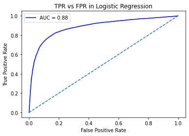

```python
# fpr and tpr for all thresholds of the logistic regression

prediction = log_reg.predict_proba(X_test)[:,1]
fpr, tpr, threshold = metrics.roc_curve(y_test, prediction)
roc_auc = metrics.auc(fpr, tpr)

plt.title('TPR vs FPR in Logistic Regression')
plt.plot(fpr, tpr, 'b', label = 'AUC = %0.2f' % roc_auc)
plt.legend()
plt.plot([0, 1], [0, 1],'--')
plt.ylabel('True Positive Rate')
plt.xlabel('False Positive Rate')
plt.show()
```

# Conclusion

There's a lot that goes into a customer feeling like they had a good or bad experience flying on a particular airline and the data we used in this tutorial recorded a lot of those specific customer experiences. Throughout this tutorial we analyzed the data to see what passenger experiences might influence other experiences and of course analyzed overall what goes into a passenger having a great experience with an airline. A lot of that analysis was done using visual means and we hope that providing multiple visuals provides for a good picture on why a passenger might have a good or bad experience. In addition to the visual analysis we also looked into predicting what a passenger's experience is overall when looking at the data from the dataset. Using random forest we were able to get 0.94 as the recall score and even higher in precision and accuracy. The high performance of predicting a passenger's experience with random forest helps support the idea that the airline asking passenger's about their experience on this dataset is asking good questions that help provide the bigger picture on how a customer felt flying that airline.

As said before, there's a lot that goes into what makes a passenger's experience and there's a lot that this dataset looked at. In just one tutorial, we were only able to scratch the surface when it comes to analyzing and predicting customer satisfaction. It would be interesting to see a future analysis of this dataset that looked at more specific features influencing satisfaction and also taking a deeper look into what doesn't seem to have much of an impact on a customer's experience.

# Extra Resources

- “Experience Is Everything: Here's How to Get It Right.” PwC, https://www.pwc.com/us/en/services/consulting/library/consumer-intelligence-series/future-of-customer-experience.html.
- "Understanding AUC - ROC Curve." TowardsDataScience, https://towardsdatascience.com/understanding-auc-roc-curve-68b2303cc9c5
- Extra information on random forest: https://towardsdatascience.com/understanding-random-forest-58381e0602d2